# STOR 565 Homework 3

Name:Qingcheng Wei

**This homework is due on Feb. 1st at 11:55 pm.** You must submit **your own** homework as knitted HTML/PDF file.

*Remark.* This homework aims to help you go through the necessary preliminary from linear regression. Even if some of the questions ask for things related to linear regression that you might not have seen before, read up online about these concepts and answer the questions to the best of your ability. I also uploaded a file named “how_fit_linear_models_with_r.html” to give you a brief introduction on how to fit lm in R.

## Computational Part

1. (*21 pt*, 7 total sub parts each 3 pts) Consider the dataset “Boston” in predicting the crime rate at Boston with associated covariates.

   ```r
   head(Boston)
   ```

   ```
   ##      crim zn indus chas   nox    rm  age    dis rad tax ptratio  black lstat
   ## 1 0.00632 18  2.31    0 0.538 6.575 65.2 4.0900   1 296    15.3 396.90  4.98
   ## 2 0.02731  0  7.07    0 0.469 6.421 78.9 4.9671   2 242    17.8 396.90  9.14
   ## 3 0.02729  0  7.07    0 0.469 7.185 61.1 4.9671   2 242    17.8 392.83  4.03
   ## 4 0.03237  0  2.18    0 0.458 6.998 45.8 6.0622   3 222    18.7 394.63  2.94
   ## 5 0.06905  0  2.18    0 0.458 7.147 54.2 6.0622   3 222    18.7 396.90  5.33
   ## 6 0.02985  0  2.18    0 0.458 6.430 58.7 6.0622   3 222    18.7 394.12  5.21
   ##   medv
   ## 1 24.0
   ## 2 21.6
   ## 3 34.7
   ## 4 33.4
   ## 5 36.2
   ## 6 28.7
   ```

   Suppose you would like to predict the crime rate with explantory variables
   - `medv`: median value of owner-occupied homes;
   - `dis`: weighted mean of distances to employement centers;
   - `indus`: proportion of non-retail business acres.

   ```r
   mod1 <- lm(crim ~ medv + dis + indus, data = Boston)
   summary(mod1)
   ```

   ```
   ##
   ## Call:
   ## lm(formula = crim ~ medv + dis + indus, data = Boston)
   ##
   ## Residuals:
   ##     Min      1Q  Median      3Q     Max
   ## -11.625  -3.345  -1.242   1.608  78.994
   ##
   ## Coefficients:
   ##             Estimate Std. Error t value Pr(>|t|)
   ## (Intercept) 11.67738    2.12190   5.503 5.95e-08 ***
   ## medv        -0.26061    0.04204  -6.199 1.19e-09 ***
   ## dis         -0.96320    0.22758  -4.232 2.75e-05 ***
   ## indus        0.13145    0.07728   1.701   0.0896 .
   ## ---
   ## Signif. codes:  0 '***' 0.001 '**' 0.01 '*' 0.05 '.' 0.1 ' ' 1
   ##
   ## Residual standard error: 7.519 on 502 degrees of freedom
   ## Multiple R-squared:  0.2404, Adjusted R-squared:  0.2358
   ## F-statistic: 52.95 on 3 and 502 DF,  p-value: < 2.2e-16
   ```

  **Hint.** You need to access to the model residuals in justifying the last sentence. The following commands might help.

  ```r
  # Obtain the residuals
  res1 <- residuals(mod1)

  # Normal QQ-plot of residuals
  plot(mod1, 2)

  # Conduct a Normality test via Shapiro-Wilk and Kolmogorov-Smirnov test
  shapiro.test(res1)
  ks.test(res1, "pnorm")
  ```

2. (*24 pt*, 4 parts each worth 6pts) For this exercise, we will use a dataset with summary information about American colleges and universities in 2013. The following code chunk retrieves it directly from the website, saving you from having to download it. The data is saved in the object called `amcoll`.

   ```r
   amcoll <- read.csv('College.csv')
   ```

   Suppose that we are curious about what factors at a university play an important role in the room and board each semester (column `Room.Board`). Answer the following questions.
1. Based on some research into the area, you believe that the five most important predictors for the room and board amount are
   - `Accept`: the number of students who accepted admission;
   - `Enroll`: the number of students who are currently enrolled;
   - `Outstate`: the out of state tuition for a semester;
   - `Books`: the average cost of books per year;
   - `Grad.Rate`: the graduation rate of the students.

   Plot a pairwise scatterplot of these variables along with the room and board cost, and comment on any trends. If you don’t know how to plot such a scatterplot, see, for example:
   - [Scatter Plot Matrices - R Base Graphs](http://www.sthda.com/english/wiki/scatter-plot-matrices-r-base-graphs)
   - [Notes on `ggplot2`](http://dept.stat.lsa.umich.edu/~jerrick/courses/stat701/notes/ggplot2.html)

   Include your pairwise scatter plot as part of what you turn in.

```r
library(ggplot2)
```

[output not shown]

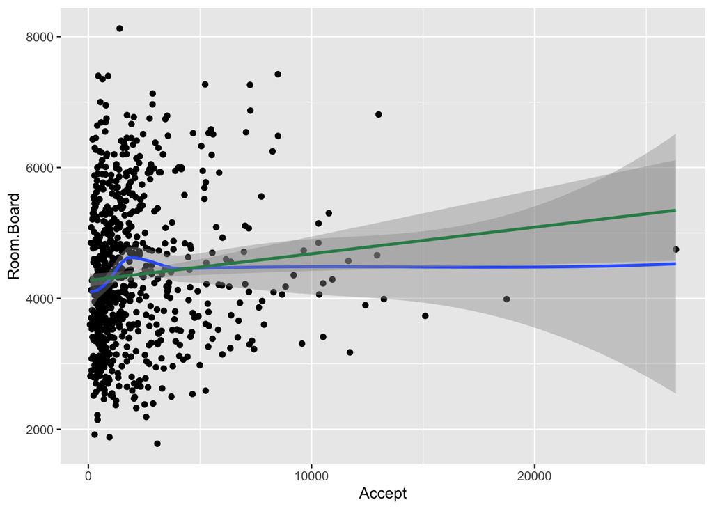

```r
ggplot(amcoll,
       aes(x = Accept,
           y = Room.Board)) +
  geom_point() +
  geom_smooth() +
  geom_smooth(method = 'lm', color = 'seagreen')
```

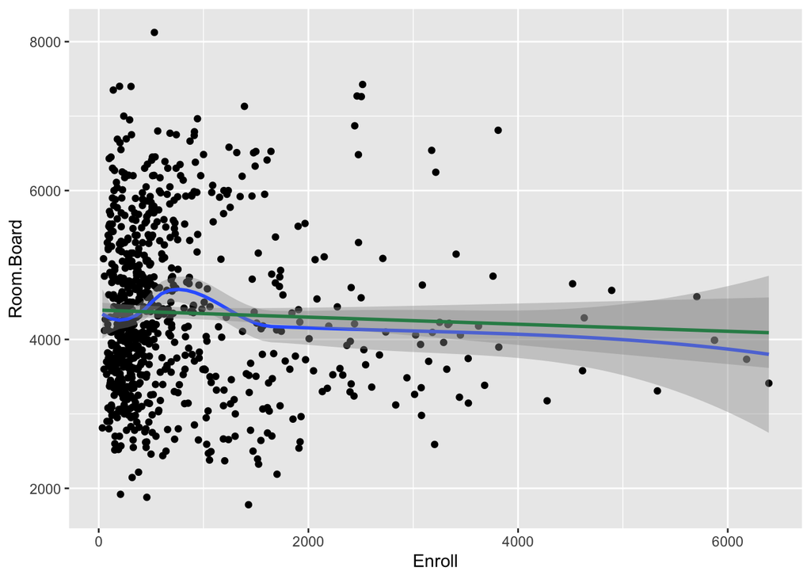

```r
ggplot(amcoll,
       aes(x = Enroll,
           y = Room.Board)) +
  geom_point() +
  geom_smooth() +
  geom_smooth(method = 'lm', color = 'seagreen')
```

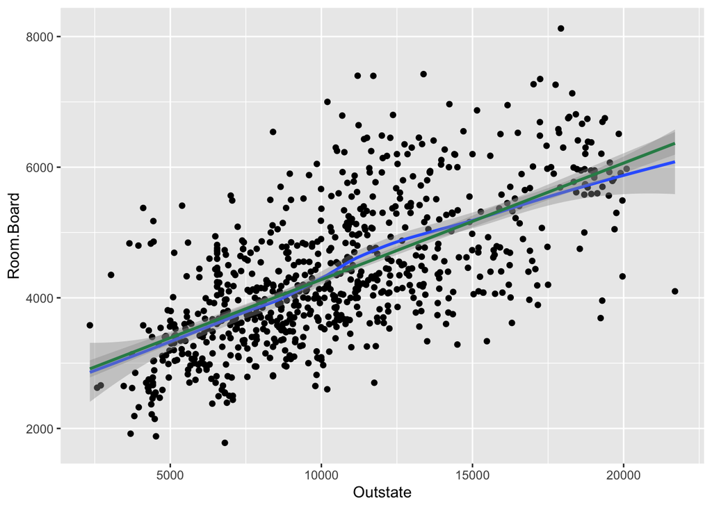

```r
ggplot(amcoll,
       aes(x = Outstate,
           y = Room.Board)) +
  geom_point() +
  geom_smooth() +
  geom_smooth(method = 'lm', color = 'seagreen')
```

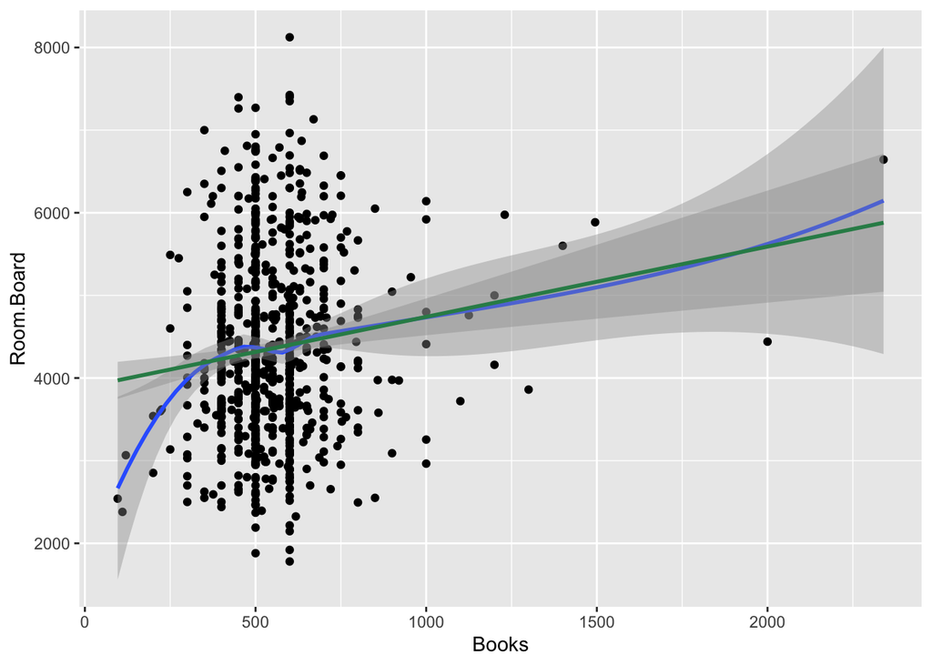

```r
ggplot(amcoll,
       aes(x = Books,
           y = Room.Board)) +
  geom_point() +
  geom_smooth() +
  geom_smooth(method = 'lm', color = 'seagreen')
```

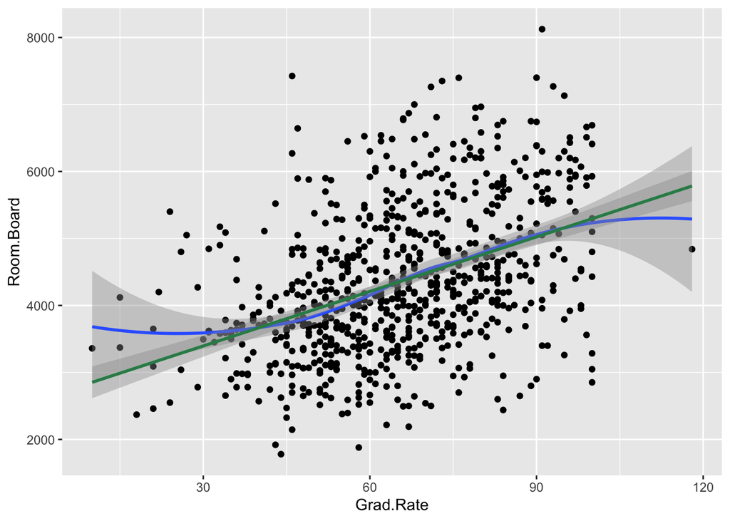

```r
ggplot(amcoll,
       aes(x = Grad.Rate,
           y = Room.Board)) +
  geom_point() +
  geom_smooth() +
  geom_smooth(method = 'lm', color = 'seagreen')
```

Based on the model, the Grad.Rate and Outstate in particular suggests an association with the Room.Board variable

2. Run a linear model of `Room.Board` on the 5 features above. Suppose we decide that $.01$ is our level of significance (so p-values have to be below $.01$ to count as significant). Discuss the findings of your linear model. In particular you should find that one of the features is **not** significant.

```r
model=lm(Room.Board~Accept+Enroll+Outstate+Grad.Rate+Books,data=amcoll)
summary(model)
```

```
##
## Call:
## lm(formula = Room.Board ~ Accept + Enroll + Outstate + Grad.Rate +
##     Books, data = amcoll)
##
## Residuals:
##     Min      1Q  Median      3Q     Max
## -2329.8  -544.4  -100.3   496.7  2880.7
##
## Coefficients:
##               Estimate Std. Error t value Pr(>|t|)
## (Intercept)  2.013e+03  1.532e+02  13.141  < 2e-16 ***
## Accept       1.409e-01  3.012e-02   4.677 3.43e-06 ***
## Enroll      -2.905e-01  8.033e-02  -3.616 0.000318 ***
## Outstate     1.590e-01  9.135e-03  17.404  < 2e-16 ***
## Grad.Rate    4.147e+00  2.071e+00   2.003 0.045544 *
## Books        6.458e-01  1.773e-01   3.642 0.000288 ***
## ---
## Signif. codes:  0 '***' 0.001 '**' 0.01 '*' 0.05 '.' 0.1 ' ' 1
##
## Residual standard error: 808.4 on 771 degrees of freedom
## Multiple R-squared:  0.4601, Adjusted R-squared:  0.4566
## F-statistic: 131.4 on 5 and 771 DF,  p-value: < 2.2e-16
```

Based on the final result and looking at the Prob value of each of t value for each coefficient. Grad.Rate is not significant cuz its p value is higher than 0.01.

3. Write a function `kfold.cv.lm()` which performs the following. You can either write this from scracth or use any standard package in R or see the book for example code etc.

   **Inputs**:
   - `k`: integer number of disjoint sets
   - `seed`: numeric value to set random number generator seed for reproducability
   - `X`: $n \times p$ design matrix
   - `y`: $n \times 1$ numeric response
   - `which.betas`: $p \times 1$ logical specifying which predictors to be included in a regression

   **Outputs**: a vector of

   $$\begin{align*}
   \mathtt{Avg.MSE} &= {1 \over 10}\sum_{i=1}^{10}(\text{the $i$-th within-fold MSE});\\
   \mathtt{Avg.MSPE} &= {1 \over 10}\sum_{i=1}^{10}(\text{the $i$-th out-of-fold MSE}),
   \end{align*}$$

   where the $i$-th within-fold MSE is obtained from training on the data other than the $i$-th fold and predicting on the training data; while the $i$-th out-of-fold MSE is obtained from training on the data other than the $i$-th fold and predicting on the $i$-th fold data.

   **Description**: performing $k$-fold cross-validation on the linear regression model of $y$ on $X$ for predictors indicated by `which.betas`. It returns both the averaged MSE based on the training data and the averaged MSPE based on the “test” data.

```r
kfold.cv.lm <- function(k, seed, X, y, which.betas){
  set.seed(seed)
  n <- nrow(X)
  fold_index <- sample(rep(1:k, length.out = n))
  avg.mse <- avg.mspe <- 0

  for(i in 1:k){
    test_index <- which(fold_index == i)
    train_index <- which(fold_index != i)

    X_train <- X[train_index, which.betas]
    y_train <- y[train_index]
    X_test <- X[test_index, which.betas]
    y_test <- y[test_index]


    data=data.frame(y_train,X_train)

    fit <- lm(y_train~.,data=data)

    y_pred_train <- predict(fit, X_train)

    y_pred_test <- predict(fit, X_test)

    avg.mse <- avg.mse + mean((y_pred_train - y_train)^2) / k

    avg.mspe <- avg.mspe + mean((y_pred_test - y_test)^2) / k
  }
  return(c(Avg.MSE = avg.mse, Avg.MSPE = avg.mspe))
}
```

4. Use your function `kfold.cv.lm()` to perform 10 folder cross validation on the college data for the following two models:
   - the full model on the 5 features above;
   - the model where you leave out the feature you found to be insgnificant in (b).

   Which of the two is a “better” model and why? Indicate your comparing criteria.

```r
library(dplyr)
X<-amcoll %>% select(-Room.Board)
y<-as.numeric(amcoll$Room.Board)
which.beta<-c("Accept","Enroll","Grad.Rate","Books","Outstate")
kfold.cv.lm(10,10,X,y,which.beta)
```

```
##  Avg.MSE Avg.MSPE
## 647484.3 670320.2
```

```r
X<-amcoll %>% select(-Room.Board)
y<-as.numeric(amcoll$Room.Board)
which.beta<-c("Accept","Enroll","Books","Outstate")
kfold.cv.lm(10,10,X,y,which.beta)
```

```
##  Avg.MSE Avg.MSPE
## 650916.2 672629.8
```